# Using the Children Weight Model

Rodrigo Zepeda Tello & Dalia Camacho García Formentí

2018-07-05

> In this vignette we explain how to use the model for children in R; we develop and explain the equations involved both for casual and advanced readers.

# Contents

- Usage in R
- Basic model explanation
- Advanced model explanation

# Usage in R

The main inputs for the body weight change model in children are:

| Input | Meaning | Optional | Default |
| --- | --- | --- | --- |
| `age` | Age (yrs) | No | - |
| `sex` | Either `'male'` or `'female'` | No | - |

As an example consider a `7` year old `'female'`:

```r
female_model1 <- child_weight(age = 7, sex = "female")
```

Furthermore, the model allows the user to input Fat and Fat Free Mass composition of the body:

| Input | Meaning | Optional | Default |
| --- | --- | --- | --- |
| `FM` | Fat Mass (kg) | Yes | Model estimate |
| `FFM` | Fat Free Mass (kg) | Yes | Model estimate |

For example, our female might have `19.9` kg of Fat Mass and `5.74` kg of Fat Free Mass:

```r
female_model2 <- child_weight(age = 7, sex = "female", FM = 19.9, FFM = 5.74)
```

Energy intake can also be inputed as a vector of daily energy consumption:

| Input | Meaning | Optional | Default |
| --- | --- | --- | --- |
| `EI` | Energy Intake per day | Yes | Model estimate |

```r
female_model3 <- child_weight(age = 7, sex = "female", FM = 19.9, FFM = 5.74,
                              EI = seq(1600, 1750, length.out = 365))
```

Other (optional) inputs include:

| Input | Meaning | Optional | Default |
| --- | --- | --- | --- |
| `days` | Number of days to run de model | Yes | $365$ |
| `dt` | Time step for Runge-Kutta 4 | Yes | $1$ |
| `checkValues` | Boolean indicating whether the model should check parameters make sense | Yes | `TRUE` |

All inputs used in the model are:

| Input | Meaning | Optional | Default |
| --- | --- | --- | --- |
| `age` | Age (yrs) | No | - |
| `sex` | Either `'male'` or `'female'` | No | - |
| `FM` | Fat Mass (kg) | Yes | Model estimate |
| `FFM` | Fat Free Mass (kg) | Yes | Model estimate |
| `EI` | Energy Intake per day | Yes | Model estimate |
| `days` | Time period (days) to run the model | Yes | $365$ |
| `dt` | Time step for Runge-Kutta 4 | Yes | $1$ |
| `checkValues` | Check for internal consistency | Yes | `TRUE` |

Finally, we remark that one can also input data from a database to estimate individual-level weight change (see the related section)

```r
#Database information
ages    <- c(8, 10, 7, 7, 12)
sexes   <- c("male", "female", "female", "male", "male")

#Returns a weight change matrix and other matrices
database_model <- child_weight(ages, sexes)
```

## Plots

Result plots can be obtained by `model_plot` function:

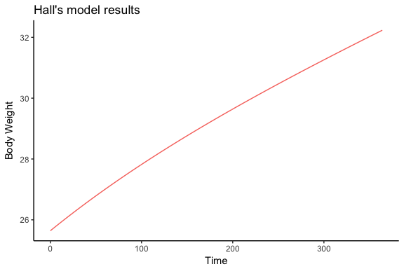

```r
model_plot(female_model2, "Body_Weight")
```

Plotting options include `"Body_Weight"`, `Fat_Mass`, and `Fat_Free_Mass`. Several can be chosen at the same time:

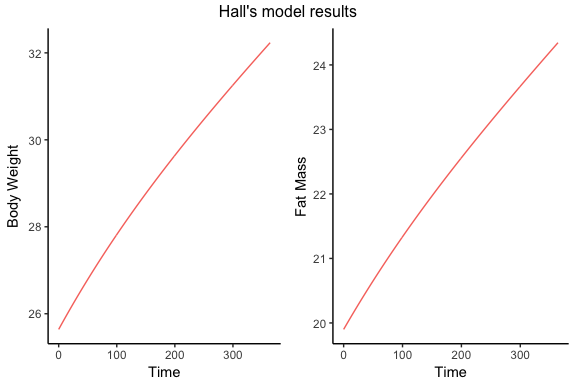

```r
model_plot(female_model2, c("Body_Weight", "Fat_Mass"))
```

Variables can also be plotted against age:

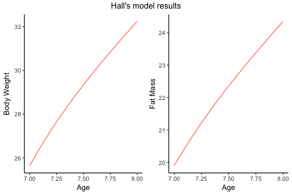

```r
model_plot(female_model2, c("Body_Weight", "Fat_Mass"), timevar = "Age")
```

## Energy

Energy intake is usually not continuously measured but measured at different and distant points in time (say 1 year apart). The function `energy_build` allows the user to interpolate different energy models between the interpolation points. For further information on the `energy_build` function see `AdultModel` vignette.

## Using Richardson’s function

The children model includes the option `richardsonparams` which is a list of parameters $list(K = NA, Q = NA, B = NA, A = NA, nu = NA, C = NA)$ representing $K, Q, \beta, A, \nu, C$. If parameters are specified, the model assumes the energy intake function is a generalized logistic function (Richardson’s function (Falkner and Tanner 2012)):
$$\begin{equation}
EI(t) = A + \frac{K-A}{(C + Q e^{-\beta \cdot t})^{1/\nu}}.
\end{equation}$$

```r
girl <- child_weight(6,"female", days=365, dt = 5,
                     richardsonparams = list(K = 2700, Q = 10,
                                             B = 12, A = 3, nu = 4,
                                             C = 1))
```

```
## Using Richardson's function
```

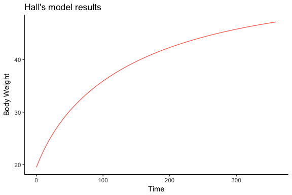

```r
model_plot(girl, "Body_Weight")
```

## Estimating weight change of a database

Vector data can also be used in the model to calculate weight change for several individuals at a time (which is quite faster than doing them individually). As an example consider the following dataset:

```r
#Database information
mydata <- data.frame(
  id = 1:5,
  age = c(8, 10, 7, 7, 12),
  sex = c("male", "female", "female", "male", "male"),
  energy = runif(5, 1500, 2000),
  prob = c(0.1, 0.2, 0.2, 0.05, 0.45))

#Get energy change with energy build function
eichange      <- energy_build(cbind(runif(5, 1500, 2000), mydata$energy), c(0, 365))

#Returns a weight change matrix and other matrices
database_model <- child_weight(mydata$age, mydata$sex, EI = t(eichange))
```

Plots can also be obtained for the population with the same command `model_plot`:

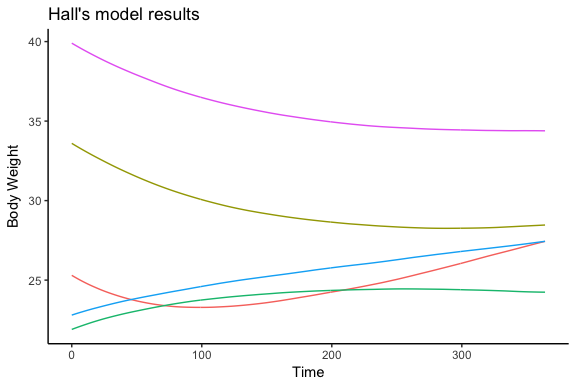

```r
model_plot(database_model, "Body_Weight")
```

Summary measures can be obtained via `model_mean` which quantifies mean for `'Body_Weight'`, `'Fat_Free_Mass'`, and `'Fat_Mass'`:

```r
model_mean(database_model, "Body_Weight")
```

```
##   time    variable group     mean  SE_mean
## 1    0 Body_Weight     1 28.70000 3.478937
## 2   15 Body_Weight     1 28.45390 3.282488
## 3   30 Body_Weight     1 28.24037 3.113004
## 4   45 Body_Weight     1 28.05701 2.964997
## 5   60 Body_Weight     1 27.90073 2.831698
## 6   75 Body_Weight     1 27.77479 2.705939
```

Mean is only estimated for some points in time, to estimate mean for the whole period, consider changing the `days` vector variable:

```r
model_mean(database_model, "Body_Weight", days = 1:365)
```

```
##   time    variable group     mean  SE_mean
## 1    1 Body_Weight     1 28.68274 3.464870
## 2    2 Body_Weight     1 28.66547 3.450882
## 3    3 Body_Weight     1 28.64821 3.437046
## 4    4 Body_Weight     1 28.63106 3.423444
## 5    5 Body_Weight     1 28.61400 3.409958
## 6    6 Body_Weight     1 28.59703 3.396601
```

Mean can also be grouped by a variable (say, `sex`):

```r
model_mean(database_model, "Body_Weight", days = 1:365, group = mydata$sex)
```

```
##   time    variable  group     mean  SE_mean
## 1    1 Body_Weight female 27.74087 4.593091
## 2    1 Body_Weight   male 29.31066 4.853987
## 3    2 Body_Weight female 27.73169 4.561625
## 4    2 Body_Weight   male 29.28798 4.840200
## 5    3 Body_Weight female 27.72240 4.530375
## 6    3 Body_Weight   male 29.26541 4.826589
```

Finally, `model_mean` can also be used to estimate `survey` means using the `svydesign` from the `survey` package:

```r
require("survey")
design <- svydesign(ids = ~id, probs = ~prob, data = mydata)
model_mean(database_model, group = mydata$sex, design = design)
```

```
##   time      variable  group      mean   SE_mean
## 1    0           Age female  8.500000 1.1858541
## 2    0           Age   male  7.655172 0.5772886
## 3    0 Fat_Free_Mass female 22.300000 3.2413346
## 4    0 Fat_Free_Mass   male 21.468966 1.4274394
## 5    0      Fat_Mass female  5.450000 1.3834965
## 6    0      Fat_Mass   male  3.286207 0.3756837
```

Additional information on the model for adults and other package functions can be obtained in the other package’s Vignettes

```r
browseVignettes("bw")
```

# Basic explanation on model’s equations

The main idea of the children’s weight model (Katan et al. 2016, Hall et al. (2013)) is that weight is determined by fat and fat free mass:
$$\begin{equation}
\underbrace{BW(t)}_{\text{Body Weight}} = \underbrace{FM(t)}_{\text{Fat Mass}} + \underbrace{FFM(t)}_{\text{Fat Free Mass}}.
\end{equation}$$
Both fat and fat free masses are interdependent; their dependencies given by the equation system:
$$\begin{equation}
\begin{aligned}
\overbrace{\dfrac{d FFM}{dt}}^{\text{Change in fat free mass}} & = \overbrace{\dfrac{1}{\rho_{FFM}}}^{\text{Scaling}} \times \overbrace{p}^{\text{Proportion of energy difference going to fat free}} \times \overbrace{(EI - E)}^{\text{Difference between intake and expenditure}}
\\ & \qquad + \underbrace{g}_{\text{Control for growth}} \\\\
\underbrace{\dfrac{d FM}{dt}}_{\text{Change in fat mass}} & = \underbrace{\dfrac{1}{\rho_{FM}}}_{\text{Scaling}} \times \underbrace{(1-p)}_{\text{Proportion of energy difference going to fat}} \times \underbrace{(EI - E)}_{\text{Difference between intake and expenditure}}
\\ & \qquad - \underbrace{g}_{\text{Control for growth}}
\end{aligned}
\end{equation}$$
Energy intake $EI$ is a function that can either be specified by the user (via the `EI` entry) or one can use a Richardson’s function (Falkner and Tanner 2012):
$$\begin{equation}
EI(t) = A + \frac{K-A}{(C + Q e^{-\beta \cdot t})^{1/\nu}}
\end{equation}$$
by specifying the individual’s parameters $K,A,C,Q,\beta,\nu$. The energy expenditure is given by a combination of the changes in fat and fat free masses as well as the masses themselves:
$$\begin{equation}
\begin{aligned}
E & = \overbrace{K}_{\text{Individual's parameter}} + \overbrace{\gamma_{FFM} FFM}^{\text{Fat Free Mass}} + \overbrace{\gamma_{FM} FM}^{\text{Fat Mass}} + \overbrace{\beta \Delta I}^{\text{Difference in intake with respect to normal growth}} \\\\\\ & \qquad + \underbrace{\delta \cdot BW}_{\text{Body weight}} + \underbrace{\eta_{FFM} \cdot \dfrac{dFFM}{dt} + \eta_{FM} \cdot \dfrac{dFM}{dt}}_{\text{Changes in fat free and fat masses}},
\end{aligned}
\end{equation}$$

Thus body weight is the result of this physiological interdependencies between the fat mass, the fat free mass, the energy intake and the expenditure. The model is further expanded in the following section.

# Advanced explanation on model’s equations

The children weight model (Katan et al. 2016, Hall et al. (2013)) considers the interactions between fat mass $FM := FM(t)$; fat free mass $FFM := FFM(t)$; an energy intake function $EI:= EI(t)$; an energy expenditure function $E := E(t)$ adjusted by a body-growth term $g(t)$. In this model, body weight is given by the sum of fat mass and fat free mass:
$$\begin{equation}
BW:= BW(t) = FM(t) + FFM(t).
\end{equation}$$

In particular, the body weight function (as a function of time $t$) depends on the individual’s sex ($\textrm{Sex}$), initial fat mass ($FM_0$), initial fat free mass ($FFM_0$), energy consumption function ($EI(t)$).

The components of body weight, $FM$ and $FFM$, are determined by a system of ordinary differential equations:
$$\begin{equation}\label{diff}
\begin{aligned}
\rho_{FFM} \cdot \dfrac{d FFM}{dt} & = p \cdot (EI - E) + g \\\\
\rho_{FM} \cdot \dfrac{d FM}{dt} & = (1-p) \cdot (EI - E) - g
\end{aligned}
\end{equation}$$

where $p = C/(C + FM)$ a ratio established by Forbes with $C = 10.4 \rho_{FFM} / \rho_{FM}$. The parameters $\rho_{FM} = 9.4 kcal/g$ ($= 9400 \textrm{ kcal}/\textrm{kg}$ and $\rho_{FFM} = (4.3 \cdot FFM_0 + 837) \textrm{ kcal}/\textrm{kg}$ where $FFM_0$ represents the amount of fat free mass (kg) at baseline.

The growth term is given by:
$$\begin{equation}\label{growth}
g:= g(t) = A e^{-(t - t_{A})/\tau_{A}} + B e^{-(t - t_{B})^2/2\tau_{B}^2} + D e^{-(t - t_{D})^2/2\tau_{D}^2},
\end{equation}$$

Energy expenditure in is given by:
$$\begin{equation}\label{energy}
E = K + \gamma_{FFM} FFM + \gamma_{FM} FM + \beta \Delta I + \delta \cdot BW + \eta_{FFM} \cdot \dfrac{dFFM}{dt} + \eta_{FM} \cdot \dfrac{dFM}{dt},
\end{equation}$$

where $K$ represents an energy expenditure constant determined by the initial energy balance ($K = 800 \textrm{ kcal}/\textrm{d}$ for males; $K = 700 \textrm{ kcal}/\textrm{d}$ for females); $\beta = 0.24$ stands for the adaptation of energy expenditure when intake is perturbed $\Delta I$; $\eta_{FM} = 180 \textrm{ kcal}/\textrm{kg}$ and $\eta_{FFM} = 230 \textrm{ kcal}/\textrm{kg}$ account for ``biochemical efficiencies associated to fat and protein synthesis’’ .

In particular, the function for physical activity $\delta$ in is given by:
$$\begin{equation}
\delta(t) = \delta_{min} + \dfrac{(\delta_{max}-\delta_{min}) P^{h}}{t^h + P^h}
\end{equation}$$

with $\delta_{min} = 10 \textrm{ kcal}/\textrm{kg}/\textrm{d}$ represents the average activity of young adults whilst $\delta_{max}$ ($\delta_{max} = 19 \textrm{ kcal}/\textrm{kg}/\textrm{d}$ and $\delta_{max} = 17 \textrm{ kcal}/\textrm{kg}/\textrm{d}$ for males and females respectively) stands for the average physical activity for young children. The parameter $P = 12 \textrm{ years}$ stands for the point of maximum physical activity whilst the constant $h = 10$ represents the rate of decline as a function of age.

The perturbation of energy intake $\Delta I$ represents the shift away from the intake associated to normal growth ($\Delta I$ in ). It was estimated by:
$$\begin{equation}
\Delta I(t) = EI(t) - I_{ref}(t)
\end{equation}$$
where:
$$\begin{equation}\label{iref}
\begin{aligned}
I_{ref}(t) & = EB_{ref} + K + (\gamma_{FFM} + \delta) FFM_{ref} + (\gamma_{FM} + \delta) FM_{ref} + \dfrac{\eta_{FFM}}{\rho_{FFM}} (p\cdot EB_{ref} + g) \\ & \qquad + \dfrac{\eta_{FM}}{\rho_{FM}} \big((1-p)\cdot EB_{ref} + g \big)
\end{aligned}
\end{equation}$$
represents the reference energy intake for normal growth. The energy balance for reference children is also of the form:
$$\begin{equation}
EB_{ref}(t) = A e^{-(t - t^{EB}_{A})/\tau^{EB}_{A}} + B e^{-(t - t^{EB}_{B})^2/2(\tau^{EB}_{B})^2} + D e^{-(t - t^{EB}_{D})^2/2(\tau_{D}^{EB})^2}.
\end{equation}$$

A closed form expression for the energy is given by:
$$\begin{equation}
E = \dfrac{K + (\gamma_{FFM} + \delta) FFM + (\gamma_{FM} + \delta) FM + \beta \cdot \Delta I + \Big( \frac{\eta_{FFM}}{\rho_{FFM}} p + \frac{\eta_{FM}}{\rho_{FM}}\cdot (1-p) \Big) \cdot EI + g \cdot \Big(\frac{\eta_{FFM}}{\rho_{FFM}} - \frac{\eta_{FM}}{\rho_{FM}} \Big)}{1 + \frac{\eta_{FFM}}{\rho_{FFM}} p + \frac{\eta_{FM}}{\rho_{FM}}\cdot (1-p) }
\end{equation}$$
To obtain the initial values for we estimated the initial fat mass using the equations from Deurenberg, Weststrate, and Seidell (1991):
$$\begin{equation}\label{fm}
FM_{0} = \begin{cases}
1.51 \cdot \text{BMI}_0 - 0.7 \cdot a - \frac{2.2}{100} \cdot BW_0 & \textrm{ if Male}\\\\
1.51 \cdot BMI_0 - 0.7 \cdot a + \frac{1.4}{100} \cdot BW_0 & \textrm{ if Female}
\end{cases}
\end{equation}$$
where $a$ represents the age (years); $\text{BMI}$ the initial body mass index ($\text{kg}/\text{m}^2$) and $BW_0$ the initial body weight of the child. The initial fat free mass is given by the difference between fat mass and body weight:
$$\begin{equation}\label{ffm}
FFM_0 = BW_0 - FM_0.
\end{equation}$$

## Solution algorithm

To solve this system of differential equations, we used a 4th order Runge-Kutta algorithm (RK4) Ascher and Greif (2011) with a stepsize $\Delta t = 1$. RK4 was programmed in `C++` for speed and connected to R via the `Rcpp` package (Eddelbuettel 2013, Eddelbuettel and François (2011)).

# Additional information

Additional information on the adult’s model, and why to use the dynamic adult model instead of other classical approaches can be found in the package’s vignettes:

```r
browseVignettes("bw")
```

# References

Ascher, Uri M, and Chen Greif. 2011. *A First Course on Numerical Methods*. SIAM.

Deurenberg, Paul, Jan A Weststrate, and Jaap C Seidell. 1991. “Body Mass Index as a Measure of Body Fatness: Age-and Sex-Specific Prediction Formulas.” *British Journal of Nutrition* 65 (2). Cambridge University Press: 105–14.

Eddelbuettel, Dirk. 2013. *Seamless R and C++ Integration with Rcpp*. New York: Springer.

Eddelbuettel, Dirk, and Romain François. 2011. “Rcpp: Seamless R and C++ Integration.” *Journal of Statistical Software* 40 (8): 1–18. http://www.jstatsoft.org/v40/i08/.

Ellis, Kenneth J, Roman J Shypailo, Steven A Abrams, and William W Wong. 2000. “The Reference Child and Adolescent Models of Body Composition: A Contemporary Comparison.” *Annals of the New York Academy of Sciences* 904 (1). Wiley Online Library: 374–82.

Falkner, Frank, and James Mourilyan Tanner. 2012. *Human Growth: A Comprehensive Treatise Volume 1 Developmental Biology Prenatal Growth*. Springer Science & Business Media.

Fomon, Samuel J, Ferdinand Haschke, Ekhard E Ziegler, and Steven E Nelson. 1982. “Body Composition of Reference Children from Birth to Age 10 Years.” *The American Journal of Clinical Nutrition* 35 (5). Am Soc Nutrition: 1169–75.

Hall, Kevin D, Nancy F Butte, Boyd A Swinburn, and Carson C Chow. 2013. “Dynamics of Childhood Growth and Obesity: Development and Validation of a Quantitative Mathematical Model.” *The Lancet Diabetes & Endocrinology* 1 (2). Elsevier: 97–105.

Haschke, F. 1989. “Body Composition During Adolescence.” *Body Composition Measurements in Infants and Children*. Ross Laboratories Columbus, OH, 76–83.

Katan, Martijn B, Janne C De Ruyter, Lothar DJ Kuijper, Carson C Chow, Kevin D Hall, and Margreet R Olthof. 2016. “Impact of Masked Replacement of Sugar-Sweetened with Sugar-Free Beverages on Body Weight Increases with Initial Bmi: Secondary Analysis of Data from an 18 Month Double–Blind Trial in Children.” *PloS One* 11 (7). Public Library of Science: e0159771.